# APPLIED STATISTICS PROJECT

# PART 1

**Importing all the necessary libraries**

```python
import numpy as np
import pandas as pd
import matplotlib.pyplot as plt
%matplotlib inline
import seaborn as sns
import scipy.stats as stats
import warnings
warnings.filterwarnings('ignore', '.*do not.*',)
```

Q1.A.

```python
PP = 400      #PP is the no. of people who planned and actually purchased
TP = 2000     #Total no. of people considered

P1 = round(PP/TP,4)
print('The joint probability of people who planned to purchase and actually purchased is %1.4f' %P1)
```

```
The joint probability of people who planned to purchase and actually purchased is 0.2000
```

Q1.B

```python
#P(Purchased an order/Planned to purchase) = P(Planned to purchase and actually purchased)/P(Planned to purchase)

P1 = (400/2000)/(500/2000)

print('Probability(Purchased an order/Planned to purchase) is equal to %1.4f' %P1)
```

```
Probability(Purchased an order/Planned to purchase) is equal to 0.8000
```

Q2.A

```python
p = 0.05 # Probability of failure of the manufactured item
n = 10   #Sample size
k = np.arange(0,11)
binomial = stats.binom.pmf(k,n,p)
binomial
```

```
array([5.98736939e-01, 3.15124705e-01, 7.46347985e-02, 1.04750594e-02,
       9.64808106e-04, 6.09352488e-05, 2.67259863e-06, 8.03789062e-08,
       1.58642578e-09, 1.85546875e-11, 9.76562500e-14])
```

```python
p2 = binomial[0]
print(' Probability that none of the items are defective is %1.4f ' %p2)
```

```
 Probability that none of the items are defective is 0.5987
```

Q2.B

```python
p3 = binomial[1]
print(' Probability that exactly one of the items is defective is %1.4f ' %p3)
```

```
 Probability that exactly one of the items is defective is 0.3151
```

Q2.C

```python
cumbinomial = stats.binom.cdf(k,n,p)
cumbinomial
```

```
array([0.59873694, 0.91386164, 0.98849644, 0.9989715 , 0.99993631,
       0.99999725, 0.99999992, 1.        , 1.        , 1.        ,
       1.        ])
```

```python
print('Probability that two or fewer of the items are defective %1.4f' %cumbinomial[2])
```

```
Probability that two or fewer of the items are defective 0.9885
```

Q2.D

```python
p3 = 1-cumbinomial[2]
print('Probability that three or more of the items are defective %1.4f'%p3)
```

```
Probability that three or more of the items are defective 0.0115
```

Q3.A

```python
rate = 3  #Sales of avg 3 cars per week
n = np.arange(0,20)
cumpoisson = stats.poisson.cdf(n,rate)
cumpoisson
```

```
array([0.04978707, 0.19914827, 0.42319008, 0.64723189, 0.81526324,
       0.91608206, 0.96649146, 0.9880955 , 0.99619701, 0.99889751,
       0.99970766, 0.99992861, 0.99998385, 0.9999966 , 0.99999933,
       0.99999988, 0.99999998, 1.        , 1.        , 1.        ])
```

```python
p1 = 1-cumpoisson[0]
print(' Probability that in a given week he will sell some car is %1.4f'%p1)
```

```
 Probability that in a given week he will sell some car is 0.9502
```

Q3.B

```python
p2 = cumpoisson[4] #Probability of selling 4 or more cars
p3 = cumpoisson[1] #Probability of selling 1 or more cars
p4 = p2-p3
print('Probability that in a given week he will sell 2 or more but less than 5 cars is %1.4f'%p4)
```

```
Probability that in a given week he will sell 2 or more but less than 5 cars is 0.6161
```

Q3.C

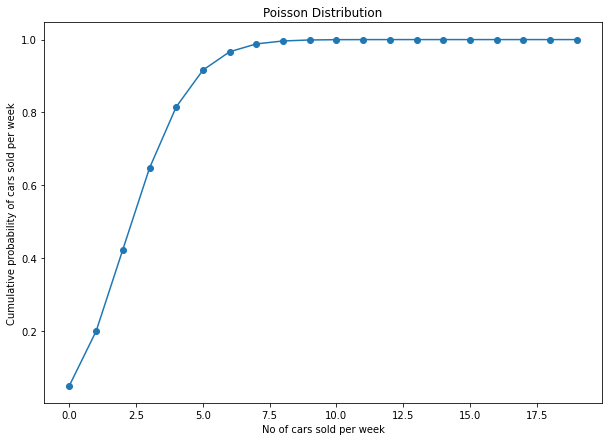

```python
plt.figure(figsize=(10,7))
plt.plot(n,cumpoisson,'o-')
plt.title('Poisson Distribution')
plt.xlabel('No of cars sold per week')
plt.ylabel('Cumulative probability of cars sold per week')
plt.show()
```

Q4.A

```python
p = 0.868 # Percentage of orders that are taken correctly
n = 3   # no. of people
k = np.arange(0,4)
binomial = stats.binom.pmf(k,n,p)
binomial
```

```
array([0.00229997, 0.0453721 , 0.2983559 , 0.65397203])
```

```python
p1 = binomial[3]
print('Probability that all three orders will be recognised correctly is %1.4f'%p1)
```

```
Probability that all three orders will be recognised correctly is 0.6540
```

Q4.B

```python
print('probability that none of the three orders will be recognised correctly is %1.4f'%binomial[0])
```

```
probability that none of the three orders will be recognised correctly is 0.0023
```

Q4.C

```python
p1 = binomial[2]+binomial[3]
print('Probability that at least two of the three orders will be recognised correctly is %1.4f'%p1)
```

```
Probability that at least two of the three orders will be recognised correctly is 0.9523
```

Q5. One of the real life industry scenario where we can use the concepts learned in Applied statistics is Aerospace/Aerostructure industry.I chose this as i am working as a stress engineer for aerostructures industry.The main aim of the work is to conduct Static, Fatigue and DT analysis on the aircraft and certify them.

1. Using the concepts learned in applied statistics we can calculate the life of aircraft components much more efficiently.
2. With the huge amount of data available, we can deploy various methods of statistical analysis and predict the probability of failure of the structure and thereby improve reliability.
3. We can also analyse the various trends in the past data and find out which of the components face higher risks of failure and improve upon them.

With the increase in the amount of data everywhere the methods of statistics find application in all areas.

# PART 2

```python
from google.colab import drive          #Mounting google drive
drive.mount('/content/drive')
```

```python
path='/content/drive/My Drive/Dataset/Basketball.csv'
df=pd.read_csv(path)                                                     #Reading the csv file into a Pandas DataFrame
```

```python
df.head()                   #First 5 datapoints
```

|  | Team | Tournament | Score | PlayedGames | WonGames | DrawnGames | LostGames | BasketScored | BasketGiven | TournamentChampion | Runner-up | TeamLaunch | HighestPositionHeld |
| --- | --- | --- | --- | --- | --- | --- | --- | --- | --- | --- | --- | --- | --- |
| 0 | Team 1 | 86 | 4385 | 2762 | 1647 | 552 | 563 | 5947 | 3140 | 33 | 23 | 1929 | 1 |
| 1 | Team 2 | 86 | 4262 | 2762 | 1581 | 573 | 608 | 5900 | 3114 | 25 | 25 | 1929 | 1 |
| 2 | Team 3 | 80 | 3442 | 2614 | 1241 | 598 | 775 | 4534 | 3309 | 10 | 8 | 1929 | 1 |
| 3 | Team 4 | 82 | 3386 | 2664 | 1187 | 616 | 861 | 4398 | 3469 | 6 | 6 | 1931to32 | 1 |
| 4 | Team 5 | 86 | 3368 | 2762 | 1209 | 633 | 920 | 4631 | 3700 | 8 | 7 | 1929 | 1 |

```python
df.shape             #Gives the no of rows and columns in the dataframe
```

```
(61, 13)
```

```python
df.tail()  #Last 5 datapoints
```

|  | Team | Tournament | Score | PlayedGames | WonGames | DrawnGames | LostGames | BasketScored | BasketGiven | TournamentChampion | Runner-up | TeamLaunch | HighestPositionHeld |
| --- | --- | --- | --- | --- | --- | --- | --- | --- | --- | --- | --- | --- | --- |
| 56 | Team 57 | 1 | 34 | 38 | 8 | 10 | 20 | 38 | 66 | - | - | 2009-10 | 20 |
| 57 | Team 58 | 1 | 22 | 30 | 7 | 8 | 15 | 37 | 57 | - | - | 1956-57 | 16 |
| 58 | Team 59 | 1 | 19 | 30 | 7 | 5 | 18 | 51 | 85 | - | - | 1951~52 | 16 |
| 59 | Team 60 | 1 | 14 | 30 | 5 | 4 | 21 | 34 | 65 | - | - | 1955-56 | 15 |
| 60 | Team 61 | 1 | - | - | - | - | - | - | - | - | - | 2017~18 | 9 |

```python
df.replace(to_replace= '-', value= 0,inplace=True) #Replaces the '-' symbols with value 0
df.tail()
```

|  | Team | Tournament | Score | PlayedGames | WonGames | DrawnGames | LostGames | BasketScored | BasketGiven | TournamentChampion | Runner-up | TeamLaunch | HighestPositionHeld |
| --- | --- | --- | --- | --- | --- | --- | --- | --- | --- | --- | --- | --- | --- |
| 56 | Team 57 | 1 | 34 | 38 | 8 | 10 | 20 | 38 | 66 | 0 | 0 | 2009-10 | 20 |
| 57 | Team 58 | 1 | 22 | 30 | 7 | 8 | 15 | 37 | 57 | 0 | 0 | 1956-57 | 16 |
| 58 | Team 59 | 1 | 19 | 30 | 7 | 5 | 18 | 51 | 85 | 0 | 0 | 1951~52 | 16 |
| 59 | Team 60 | 1 | 14 | 30 | 5 | 4 | 21 | 34 | 65 | 0 | 0 | 1955-56 | 15 |
| 60 | Team 61 | 1 | 0 | 0 | 0 | 0 | 0 | 0 | 0 | 0 | 0 | 2017~18 | 9 |

```python
df.info()    #Gives information about the values in dataframe and its datatypes
```

```
<class 'pandas.core.frame.DataFrame'>
RangeIndex: 61 entries, 0 to 60
Data columns (total 13 columns):
 #   Column               Non-Null Count  Dtype
---  ------               --------------  -----
 0   Team                 61 non-null     object
 1   Tournament           61 non-null     int64
 2   Score                61 non-null     object
 3   PlayedGames          61 non-null     object
 4   WonGames             61 non-null     object
 5   DrawnGames           61 non-null     object
 6   LostGames            61 non-null     object
 7   BasketScored         61 non-null     object
 8   BasketGiven          61 non-null     object
 9   TournamentChampion   61 non-null     object
 10  Runner-up            61 non-null     object
 11  TeamLaunch           61 non-null     object
 12  HighestPositionHeld  61 non-null     int64
dtypes: int64(2), object(11)
memory usage: 6.3+ KB
```

```python
#Many numeric columns has type value of object which is converted in to int64
df[['Score','PlayedGames','WonGames','DrawnGames','LostGames','BasketScored','BasketGiven','TournamentChampion','Runner-up']]=df[['Score','PlayedGames','WonGames','DrawnGames','LostGames','BasketScored','BasketGiven','TournamentChampion','Runner-up']].apply(pd.to_numeric)
df.info()
```

```
<class 'pandas.core.frame.DataFrame'>
RangeIndex: 61 entries, 0 to 60
Data columns (total 13 columns):
 #   Column               Non-Null Count  Dtype
---  ------               --------------  -----
 0   Team                 61 non-null     object
 1   Tournament           61 non-null     int64
 2   Score                61 non-null     int64
 3   PlayedGames          61 non-null     int64
 4   WonGames             61 non-null     int64
 5   DrawnGames           61 non-null     int64
 6   LostGames            61 non-null     int64
 7   BasketScored         61 non-null     int64
 8   BasketGiven          61 non-null     int64
 9   TournamentChampion   61 non-null     int64
 10  Runner-up            61 non-null     int64
 11  TeamLaunch           61 non-null     object
 12  HighestPositionHeld  61 non-null     int64
dtypes: int64(11), object(2)
memory usage: 6.3+ KB
```

```python
df.describe()      #Gives statistical summary of the dataset
```

|  | Tournament | Score | PlayedGames | WonGames | DrawnGames | LostGames | BasketScored | BasketGiven | TournamentChampion | Runner-up | HighestPositionHeld |
| --- | --- | --- | --- | --- | --- | --- | --- | --- | --- | --- | --- |
| count | 61.000000 | 61.000000 | 61.000000 | 61.000000 | 61.000000 | 61.000000 | 61.000000 | 61.000000 | 61.000000 | 61.000000 | 61.000000 |
| mean | 24.000000 | 901.426230 | 796.819672 | 303.967213 | 188.934426 | 303.754098 | 1140.344262 | 1140.229508 | 1.426230 | 1.409836 | 7.081967 |
| std | 26.827225 | 1134.899121 | 876.282765 | 406.991030 | 201.799477 | 294.708594 | 1506.740211 | 1163.710766 | 5.472535 | 4.540107 | 5.276663 |
| min | 1.000000 | 0.000000 | 0.000000 | 0.000000 | 0.000000 | 0.000000 | 0.000000 | 0.000000 | 0.000000 | 0.000000 | 1.000000 |
| 25% | 4.000000 | 96.000000 | 114.000000 | 34.000000 | 24.000000 | 62.000000 | 153.000000 | 221.000000 | 0.000000 | 0.000000 | 3.000000 |
| 50% | 12.000000 | 375.000000 | 423.000000 | 123.000000 | 95.000000 | 197.000000 | 430.000000 | 632.000000 | 0.000000 | 0.000000 | 6.000000 |
| 75% | 38.000000 | 1351.000000 | 1318.000000 | 426.000000 | 330.000000 | 563.000000 | 1642.000000 | 1951.000000 | 0.000000 | 0.000000 | 10.000000 |
| max | 86.000000 | 4385.000000 | 2762.000000 | 1647.000000 | 633.000000 | 1070.000000 | 5947.000000 | 3889.000000 | 33.000000 | 25.000000 | 20.000000 |

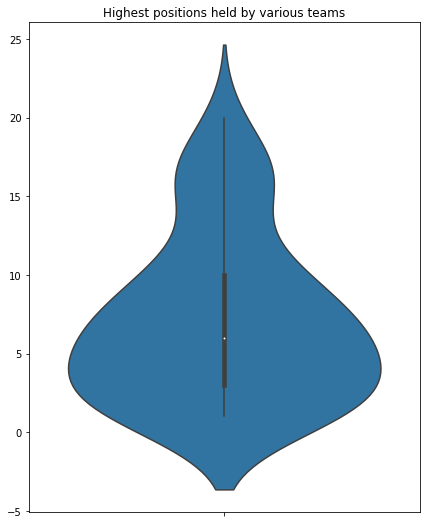

```python
plt.figure(figsize=(7,9))
sns.violinplot(data=df,y='HighestPositionHeld',orient='v');
plt.title('Highest positions held by various teams');
plt.ylabel(None);
```

Plot shows the highest positions attained by different teams

```python
# Adding a new column showing the tournament win ratio
champ=df['TournamentChampion']/df['Tournament']
df.insert(loc=10,column='Tour_win_ratio',value=champ)
df.head()
```

|  | Team | Tournament | Score | PlayedGames | WonGames | DrawnGames | LostGames | BasketScored | BasketGiven | TournamentChampion | Tour_win_ratio | Runner-up | TeamLaunch | HighestPositionHeld |
| --- | --- | --- | --- | --- | --- | --- | --- | --- | --- | --- | --- | --- | --- | --- |
| 0 | Team 1 | 86 | 4385 | 2762 | 1647 | 552 | 563 | 5947 | 3140 | 33 | 0.383721 | 23 | 1929 | 1 |
| 1 | Team 2 | 86 | 4262 | 2762 | 1581 | 573 | 608 | 5900 | 3114 | 25 | 0.290698 | 25 | 1929 | 1 |
| 2 | Team 3 | 80 | 3442 | 2614 | 1241 | 598 | 775 | 4534 | 3309 | 10 | 0.125000 | 8 | 1929 | 1 |
| 3 | Team 4 | 82 | 3386 | 2664 | 1187 | 616 | 861 | 4398 | 3469 | 6 | 0.073171 | 6 | 1931to32 | 1 |
| 4 | Team 5 | 86 | 3368 | 2762 | 1209 | 633 | 920 | 4631 | 3700 | 8 | 0.093023 | 7 | 1929 | 1 |

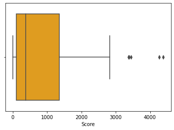

```python
sns.boxplot(data=df,x='Score',color='orange');      #Shows the 5 point summary of Scores of different teams
```

There are a few outliers

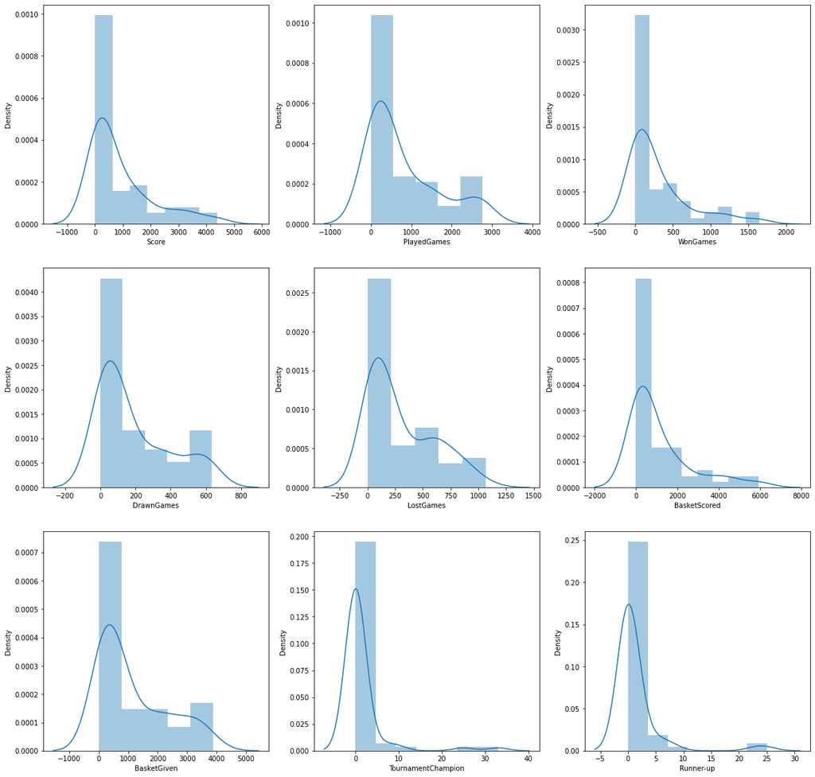

```python
col=['Score','PlayedGames','WonGames','DrawnGames','LostGames','BasketScored','BasketGiven','TournamentChampion','Runner-up']
index=1
plt.figure(figsize=(20,20))
for i in col:
  plt.subplot(3,3,index);
  sns.distplot(df[i],kde=True);
  index+=1
```

The Distribution plots for attributes of the dataset

```python
#Selecting the top 5 teams in terms of Games won,Tournament win ratio and Scores
df.nlargest(5,['Score'])
```

|  | Team | Tournament | Score | PlayedGames | WonGames | DrawnGames | LostGames | BasketScored | BasketGiven | TournamentChampion | Tour_win_ratio | Runner-up | TeamLaunch | HighestPositionHeld |
| --- | --- | --- | --- | --- | --- | --- | --- | --- | --- | --- | --- | --- | --- | --- |
| 0 | Team 1 | 86 | 4385 | 2762 | 1647 | 552 | 563 | 5947 | 3140 | 33 | 0.383721 | 23 | 1929 | 1 |
| 1 | Team 2 | 86 | 4262 | 2762 | 1581 | 573 | 608 | 5900 | 3114 | 25 | 0.290698 | 25 | 1929 | 1 |
| 2 | Team 3 | 80 | 3442 | 2614 | 1241 | 598 | 775 | 4534 | 3309 | 10 | 0.125000 | 8 | 1929 | 1 |
| 3 | Team 4 | 82 | 3386 | 2664 | 1187 | 616 | 861 | 4398 | 3469 | 6 | 0.073171 | 6 | 1931to32 | 1 |
| 4 | Team 5 | 86 | 3368 | 2762 | 1209 | 633 | 920 | 4631 | 3700 | 8 | 0.093023 | 7 | 1929 | 1 |

```python
df.nlargest(5,['WonGames'])
```

|  | Team | Tournament | Score | PlayedGames | WonGames | DrawnGames | LostGames | BasketScored | BasketGiven | TournamentChampion | Tour_win_ratio | Runner-up | TeamLaunch | HighestPositionHeld |
| --- | --- | --- | --- | --- | --- | --- | --- | --- | --- | --- | --- | --- | --- | --- |
| 0 | Team 1 | 86 | 4385 | 2762 | 1647 | 552 | 563 | 5947 | 3140 | 33 | 0.383721 | 23 | 1929 | 1 |
| 1 | Team 2 | 86 | 4262 | 2762 | 1581 | 573 | 608 | 5900 | 3114 | 25 | 0.290698 | 25 | 1929 | 1 |
| 2 | Team 3 | 80 | 3442 | 2614 | 1241 | 598 | 775 | 4534 | 3309 | 10 | 0.125000 | 8 | 1929 | 1 |
| 4 | Team 5 | 86 | 3368 | 2762 | 1209 | 633 | 920 | 4631 | 3700 | 8 | 0.093023 | 7 | 1929 | 1 |
| 3 | Team 4 | 82 | 3386 | 2664 | 1187 | 616 | 861 | 4398 | 3469 | 6 | 0.073171 | 6 | 1931to32 | 1 |

```python
df.nlargest(5,['Tour_win_ratio'])
```

|  | Team | Tournament | Score | PlayedGames | WonGames | DrawnGames | LostGames | BasketScored | BasketGiven | TournamentChampion | Tour_win_ratio | Runner-up | TeamLaunch | HighestPositionHeld |
| --- | --- | --- | --- | --- | --- | --- | --- | --- | --- | --- | --- | --- | --- | --- |
| 0 | Team 1 | 86 | 4385 | 2762 | 1647 | 552 | 563 | 5947 | 3140 | 33 | 0.383721 | 23 | 1929 | 1 |
| 1 | Team 2 | 86 | 4262 | 2762 | 1581 | 573 | 608 | 5900 | 3114 | 25 | 0.290698 | 25 | 1929 | 1 |
| 2 | Team 3 | 80 | 3442 | 2614 | 1241 | 598 | 775 | 4534 | 3309 | 10 | 0.125000 | 8 | 1929 | 1 |
| 4 | Team 5 | 86 | 3368 | 2762 | 1209 | 633 | 920 | 4631 | 3700 | 8 | 0.093023 | 7 | 1929 | 1 |
| 3 | Team 4 | 82 | 3386 | 2664 | 1187 | 616 | 861 | 4398 | 3469 | 6 | 0.073171 | 6 | 1931to32 | 1 |

From the above outputs it is evident that Team 1,Team 2, Team 3, Team 4 and Team 5 are the best teams that has the highest no of wins,score and Tournament wins.

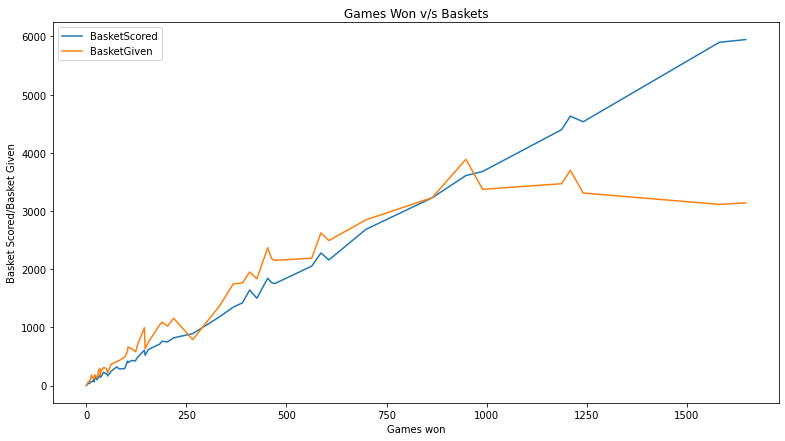

```python
plt.figure(figsize=(13,7))
sns.lineplot(data=df,x='WonGames',y='BasketScored');
sns.lineplot(data=df,x='WonGames',y='BasketGiven');
plt.legend(labels=['BasketScored','BasketGiven']);
plt.title('Games Won v/s Baskets');
plt.xlabel('Games won');
plt.ylabel('Basket Scored/Basket Given');
```

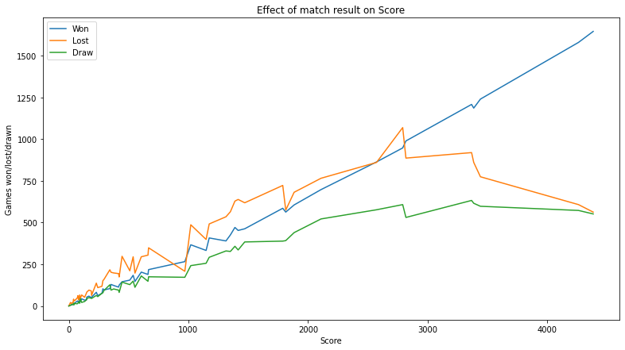

```python
plt.figure(figsize=(13,7));
sns.lineplot(data=df,x='Score',y='WonGames');
sns.lineplot(data=df,x='Score',y='LostGames');
sns.lineplot(data=df,x='Score',y='DrawnGames');
plt.legend(labels=['Won','Lost','Draw']);
plt.title('Effect of match result on Score');
plt.xlabel('Score');
plt.ylabel('Games won/lost/drawn');
```

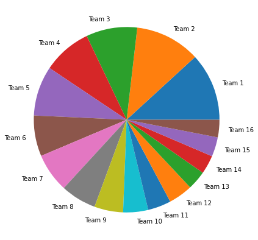

```python
plt.figure(figsize=(20,7))
plt.pie(list(df["WonGames"][:16]),labels=list(df["Team"][:16]))
plt.show()
```

The no. of games won by first 16 teams is shown as a pie chart.

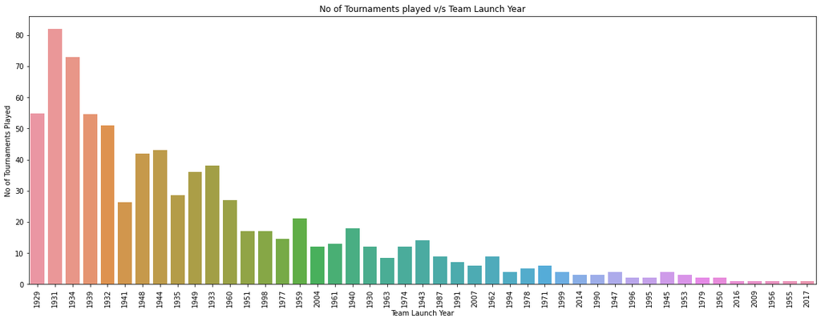

```python
plt.figure(figsize=(20,7))
df['TeamLaunch'] = df['TeamLaunch'].apply(lambda x: x[:4])
sns.barplot(data=df,x='TeamLaunch',y='Tournament',ci=False);
plt.xticks(rotation=90);
plt.title('No of Tournaments played v/s Team Launch Year');
plt.xlabel('Team Launch Year');
plt.ylabel('No of Tournaments Played');
```

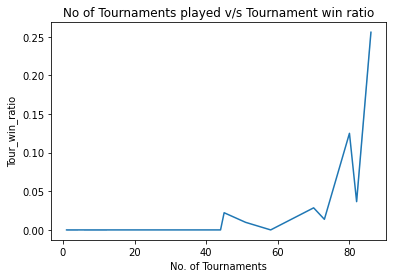

```python
sns.lineplot(data=df,x='Tournament',y='Tour_win_ratio',ci=False);
plt.title('No of Tournaments played v/s Tournament win ratio');
plt.xlabel('No. of Tournaments');
```

More the no. of tournaments played more experience gained by the players and more the no. of wins

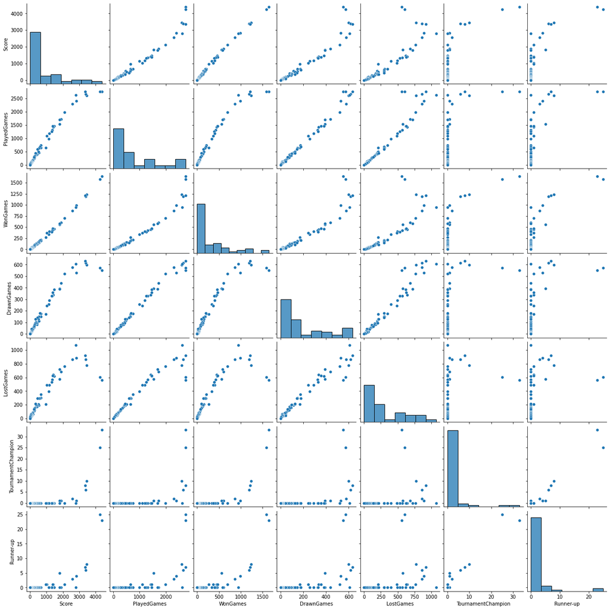

```python
sns.pairplot(data=df[['Score','PlayedGames','WonGames','DrawnGames','LostGames','TournamentChampion','Runner-up']]) #Pair plot
```

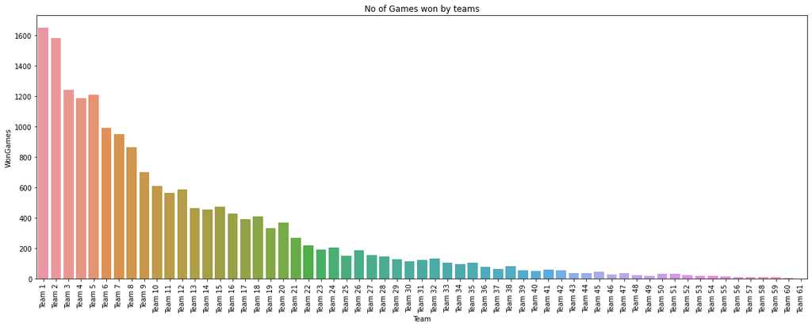

```python
plt.figure(figsize=(20,7))
sns.barplot(data=df,x='Team',y='WonGames');
plt.xticks(rotation=90);
plt.title('No of Games won by teams');
```

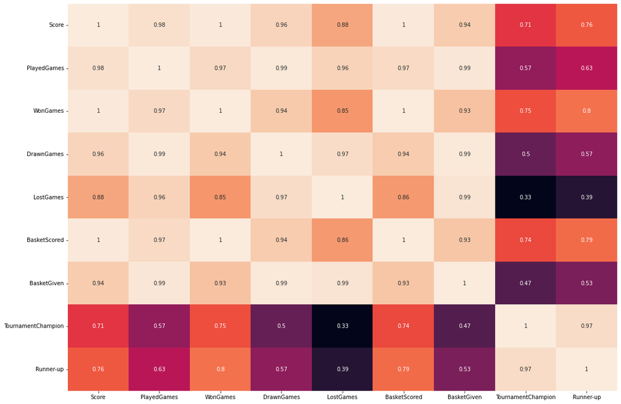

```python
plt.figure(figsize=(18,13));
sns.heatmap(data=df[['Score','PlayedGames','WonGames','DrawnGames','LostGames','BasketScored','BasketGiven','TournamentChampion','Runner-up']].corr(),annot=True,cbar=False);
```

Shows the correlation between various attributes of the dataset.

A few suggestions:

1. Quality of data - The quality of data could have been a little more better like the column such as Team Launch contains multiple year data like an interval of years.
2. Quantity of data - There are around 61 teams information that has been provided.The more the amount of data the more accurate inferences we can make out.
3. Velocity of data - We can gather more information quickly and efficiently if we keep recording the information after every matches.
4. Variety of data - The variety help us distinguish between various datapoints more efficiently and this can be done by improving the amount of information given by the dataset.

The final conclusion is that the Company X can approach any of the first 5 teams which has played more games,has more wins and experience.

# PART 3

```python
path='/content/drive/My Drive/Dataset/CompanyX_EU.csv'
df1=pd.read_csv(path)    #Reading the csv file into a Pandas DataFrame
```

```python
df1.head()
```

|  | Startup | Product | Funding | Event | Result | OperatingState |
| --- | --- | --- | --- | --- | --- | --- |
| 0 | 2600Hz | 2600hz.com | NaN | Disrupt SF 2013 | Contestant | Operating |
| 1 | 3DLT | 3dlt.com | $630K | Disrupt NYC 2013 | Contestant | Closed |
| 2 | 3DPrinterOS | 3dprinteros.com | NaN | Disrupt SF 2016 | Contestant | Operating |
| 3 | 3Dprintler | 3dprintler.com | $1M | Disrupt NY 2016 | Audience choice | Operating |
| 4 | 42 Technologies | 42technologies.com | NaN | Disrupt NYC 2013 | Contestant | Operating |

```python
df1.tail()
```

|  | Startup | Product | Funding | Event | Result | OperatingState |
| --- | --- | --- | --- | --- | --- | --- |
| 657 | Zivity | zivity.com | $8M | TC40 2007 | Contestant | Operating |
| 658 | Zmorph | zmorph3d.com | $1M | - | Audience choice | Operating |
| 659 | Zocdoc | zocdoc.com | $223M | TC40 2007 | Contestant | Operating |
| 660 | Zula | zulaapp.com | $3.4M | Disrupt SF 2013 | Audience choice | Operating |
| 661 | Zumper | zumper.com | $31.5M | Disrupt SF 2012 | Finalist | Operating |

```python
df1.shape
```

```
(662, 6)
```

```python
df1.info()
```

```
<class 'pandas.core.frame.DataFrame'>
RangeIndex: 662 entries, 0 to 661
Data columns (total 6 columns):
 #   Column          Non-Null Count  Dtype
---  ------          --------------  -----
 0   Startup         662 non-null    object
 1   Product         656 non-null    object
 2   Funding         448 non-null    object
 3   Event           662 non-null    object
 4   Result          662 non-null    object
 5   OperatingState  662 non-null    object
dtypes: object(6)
memory usage: 31.2+ KB
```

```python
df1.isnull().sum() #Check for null values
```

```
Startup             0
Product             6
Funding           214
Event               0
Result              0
OperatingState      0
dtype: int64
```

```python
df1.dropna(axis=0,inplace=True) #drop the null values
df1.isnull().sum()
```

```
Startup           0
Product           0
Funding           0
Event             0
Result            0
OperatingState    0
dtype: int64
```

```python
#Making a new column of Funds_in_million with numeric values
df1.loc[:,'Funds_in_million'] = df1['Funding'].apply(lambda x:float(x[1:-1])/1000 if x[-1] =='K'else(float(x[1:-1])*1000 if x[-1] =='B' else float(x[1:-1])))
df1.info()
```

```
<class 'pandas.core.frame.DataFrame'>
Int64Index: 446 entries, 1 to 661
Data columns (total 7 columns):
 #   Column            Non-Null Count  Dtype
---  ------            --------------  -----
 0   Startup           446 non-null    object
 1   Product           446 non-null    object
 2   Funding           446 non-null    object
 3   Event             446 non-null    object
 4   Result            446 non-null    object
 5   OperatingState    446 non-null    object
 6   Funds_in_million  446 non-null    float64
dtypes: float64(1), object(6)
memory usage: 27.9+ KB
```

```python
df1['Funds_in_million']
```

```
1        0.63
3        1.00
5       19.30
6       29.00
10       1.80
        ...
657      8.00
658      1.00
659    223.00
660      3.40
661     31.50
Name: Funds_in_million, Length: 446, dtype: float64
```

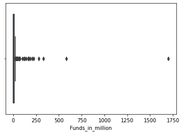

```python
sns.boxplot(data=df1,x='Funds_in_million');      #box plot for Funds in million
```

```python
#Checking Q1,Q3 and IQR
q1=df1.quantile(0.25)
q3=df1.quantile(0.75)
iqr=q3-q1
print('q1 = %1.4f'%q1)
print('q2 = %1.4f'%q3)
print('iqr = %1.4f'%iqr)
```

```
q1 = 0.7452
q2 = 9.4750
iqr = 8.7297
```

```python
upper_bound = q3 +(1.5 * iqr)         #Checking for upperfence value
upper_bound=upper_bound.loc['Funds_in_million']
upper_bound
```

```
22.569625
```

```python
df_no_outlier=df1[df1.Funds_in_million <  upper_bound]  #dataframe containing only values below the upperfence
df_no_outlier.head()
```

|  | Startup | Product | Funding | Event | Result | OperatingState | Funds_in_million |
| --- | --- | --- | --- | --- | --- | --- | --- |
| 1 | 3DLT | 3dlt.com | $630K | Disrupt NYC 2013 | Contestant | Closed | 0.63 |
| 3 | 3Dprintler | 3dprintler.com | $1M | Disrupt NY 2016 | Audience choice | Operating | 1.00 |
| 5 | 5to1 | 5to1.com | $19.3M | TC50 2009 | Contestant | Acquired | 19.30 |
| 10 | AdhereTech | adheretech.com | $1.8M | Hardware Battlefield 2014 | Contestant | Operating | 1.80 |
| 11 | AdRocket | adrocket.com | $1M | TC50 2008 | Contestant | Closed | 1.00 |

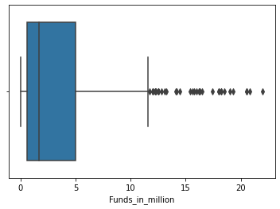

```python
sns.boxplot(data=df_no_outlier,x='Funds_in_million');       #Box plot after removing the outliers above upper fence
```

```python
df_outlier=df1[df1.Funds_in_million >  upper_bound]
len(df_outlier['Funds_in_million'])                  # No of values above the upperfence
```

```
60
```

The no. of outliers greater than upper fence is 60.

```python
#dropping all the outliers and copying it to a new dataframe
df4=df1.copy()
df4.drop(df4[df4.Funds_in_million>upper_bound].index,inplace=True)
df4.head()
```

|  | Startup | Product | Funding | Event | Result | OperatingState | Funds_in_million |
| --- | --- | --- | --- | --- | --- | --- | --- |
| 1 | 3DLT | 3dlt.com | $630K | Disrupt NYC 2013 | Contestant | Closed | 0.63 |
| 3 | 3Dprintler | 3dprintler.com | $1M | Disrupt NY 2016 | Audience choice | Operating | 1.00 |
| 5 | 5to1 | 5to1.com | $19.3M | TC50 2009 | Contestant | Acquired | 19.30 |
| 10 | AdhereTech | adheretech.com | $1.8M | Hardware Battlefield 2014 | Contestant | Operating | 1.80 |
| 11 | AdRocket | adrocket.com | $1M | TC50 2008 | Contestant | Closed | 1.00 |

```python
#Frequency of Operating state
df4['OperatingState'].value_counts()
```

```
Operating    275
Closed        56
Acquired      55
Name: OperatingState, dtype: int64
```

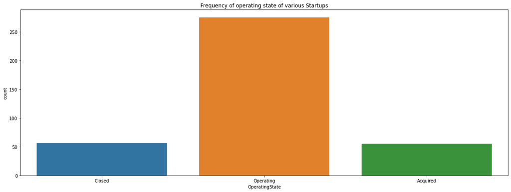

```python
plt.figure(figsize=(20,7))
sns.countplot(data=df4,x='OperatingState');
plt.title('Frequency of operating state of various Startups');
```

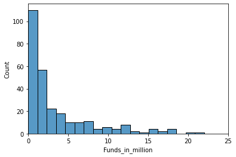

```python
#Variation in funds raised by companies that are still operating vs companies that are closed down
sns.histplot(data=df4,x = df4[df4['OperatingState'] == 'Operating'].Funds_in_million,);
plt.xlim(0,25);
```

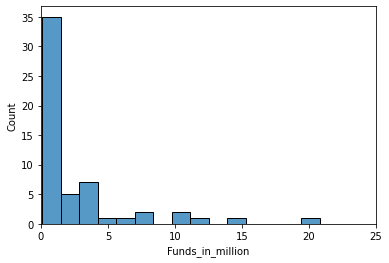

```python
sns.histplot(data=df4,x = df4[df4['OperatingState'] == 'Closed'].Funds_in_million);
plt.xlim(0,25);
```

Null hypothesis : Ho = "The funds raised by the companies that are operating and closed down do no differ significantly"  
Alternate hypothesis: Ha = "The funds raised by the companies that are operating and closed down differ significantly"

```python
Ho = "The funds raised by the companies that are operating and closed down do no differ significantly"
Ha = "The funds raised by the companies that are operating and closed down differ significantly"

x = np.array(df4[(df4['OperatingState'] == 'Closed')].Funds_in_million)
y = np.array(df4[(df4['OperatingState'] == 'Operating')].Funds_in_million)

t, p_value  = stats.ttest_ind(x,y, axis = 0)  #Two sample t_test
if p_value < 0.05: # Setting our significance level at 5%
    print(f'{Ha} as the p_value ({p_value}) < 0.05')
else:
    print(f'{Ho} as the p_value ({p_value}) > 0.05')
```

```
The funds raised by the companies that are operating and closed down do no differ significantly as the p_value (0.1931747168826862) > 0.05
```

```python
#making a copy of the dataframe
df3 = df4.copy()
```

```python
#Frequency of result variables
df3['Result'].value_counts()
```

```
Contestant         282
Finalist            52
Audience choice     20
Winner              17
Runner up           15
Name: Result, dtype: int64
```

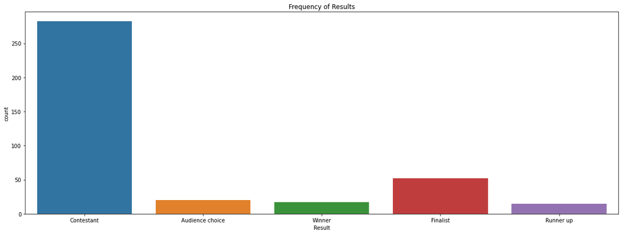

```python
plt.figure(figsize=(20,7))
sns.countplot(data=df3,x='Result');
plt.title('Frequency of Results');
```

```python
#percentage of winners that are still operating and percentage of contestants that are still operating
Winner_pct= ((df3[(df3['Result']=='Winner') & (df3['OperatingState']=='Operating')].shape[0])/df3.shape[0])*100
Contestant_pct= ((df3[(df3['Result']=='Contestant') & (df3['OperatingState']=='Operating')].shape[0])/df3.shape[0])*100

print('Percentage of winners still operating %1.4f'%Winner_pct)
print('Percentage of Contestants still operating %1.4f'%Contestant_pct)
```

```
Percentage of winners still operating 3.1088
Percentage of Contestants still operating 50.2591
```

Null hypothesis: Proportion of Companies operating between winners and contestants do not differ significantly.

Alternate hypothesis: Proportion of Companies operating between winners and contestants differ significantly.

```python
df2=df3[(df3['Result']=='Winner') + (df3['Result']=='Contestant')].copy()
df2.head()
```

|  | Startup | Product | Funding | Event | Result | OperatingState | Funds_in_million |
| --- | --- | --- | --- | --- | --- | --- | --- |
| 1 | 3DLT | 3dlt.com | $630K | Disrupt NYC 2013 | Contestant | Closed | 0.63 |
| 5 | 5to1 | 5to1.com | $19.3M | TC50 2009 | Contestant | Acquired | 19.30 |
| 10 | AdhereTech | adheretech.com | $1.8M | Hardware Battlefield 2014 | Contestant | Operating | 1.80 |
| 11 | AdRocket | adrocket.com | $1M | TC50 2008 | Contestant | Closed | 1.00 |
| 13 | Agrilyst | agrilyst.com | $1M | Disrupt SF 2015 | Winner | Operating | 1.00 |

```python
crosstab=pd.crosstab(df2['OperatingState'],df2['Result'])
crosstab
```

| Result OperatingState | Contestant | Winner |
| --- | --- | --- |
| Acquired | 39 | 5 |
| Closed | 49 | 0 |
| Operating | 194 | 12 |

```python
Ho = "Proportion of Companies operating between winners and contestants are same"
Ha = "Proportion of Companies operating between winners and contestants are different"

chi, p_value, dof, expected =  stats.chi2_contingency(crosstab)            #Chi_square test
if p_value < 0.05:  # Setting our significance level at 5%
    print(f'{Ha} as the p_value ({p_value.round(3)}) < 0.05')
else:
    print(f'{Ho} as the p_value ({p_value.round(3)}) > 0.05')
crosstab
```

```
Proportion of Companies operating between winners and contestants are same as the p_value (0.061) > 0.05
```

| Result OperatingState | Contestant | Winner |
| --- | --- | --- |
| Acquired | 39 | 5 |
| Closed | 49 | 0 |
| Operating | 194 | 12 |

```python
#Select only the Event that has ‘disrupt’ keyword from 2013 onwards.
df3['Year']=df3['Event'].apply(lambda x: x[-5:])  #Make a column Year by extracting last 5 strings in Event column
df3['Year'].replace(to_replace='-',value=0,inplace=True)
df3['Year']=df3['Year'].apply(pd.to_numeric)      #Convert Year column to numeric value
df3.info()
```

```
<class 'pandas.core.frame.DataFrame'>
Int64Index: 386 entries, 1 to 660
Data columns (total 8 columns):
 #   Column            Non-Null Count  Dtype
---  ------            --------------  -----
 0   Startup           386 non-null    object
 1   Product           386 non-null    object
 2   Funding           386 non-null    object
 3   Event             386 non-null    object
 4   Result            386 non-null    object
 5   OperatingState    386 non-null    object
 6   Funds_in_million  386 non-null    float64
 7   Year              386 non-null    int64
dtypes: float64(1), int64(1), object(6)
memory usage: 35.2+ KB
```

```python
df3[(df3['Event']=='Disrupt') + (df3['Year']>=2013)] #Selecting only the Event that has ‘disrupt’ keyword from 2013 onwards.
```

|  | Startup | Product | Funding | Event | Result | OperatingState | Funds_in_million | Year |
| --- | --- | --- | --- | --- | --- | --- | --- | --- |
| 1 | 3DLT | 3dlt.com | $630K | Disrupt NYC 2013 | Contestant | Closed | 0.630 | 2013 |
| 3 | 3Dprintler | 3dprintler.com | $1M | Disrupt NY 2016 | Audience choice | Operating | 1.000 | 2016 |
| 10 | AdhereTech | adheretech.com | $1.8M | Hardware Battlefield 2014 | Contestant | Operating | 1.800 | 2014 |
| 13 | Agrilyst | agrilyst.com | $1M | Disrupt SF 2015 | Winner | Operating | 1.000 | 2015 |
| 14 | Aiden | aiden.ai | $750K | Disrupt London 2016 | Contestant | Operating | 0.750 | 2016 |
| ... | ... | ... | ... | ... | ... | ... | ... | ... |
| 638 | Wiivv | wiivv.com | $12.2M | Hardware Battlefield 2016 | Runner up | Operating | 12.200 | 2016 |
| 641 | Workspot | workspot.com | $15.8M | Disrupt NYC 2013 | Contestant | Operating | 15.800 | 2013 |
| 642 | Xendo | xendo.com | $28K | Disrupt SF 2014 | Contestant | Acquired | 0.028 | 2014 |
| 646 | YayPay Inc | yaypay.com | $900K | Disrupt London 2015 | Contestant | Operating | 0.900 | 2015 |
| 660 | Zula | zulaapp.com | $3.4M | Disrupt SF 2013 | Audience choice | Operating | 3.400 | 2013 |

219 rows × 8 columns